# From collocations to timeline

This notebook includes functions for building collocation networks and analyzing selected collocations on a timeline.

First, collocations for search terms are fetched from a folder including text files that are already lemmatized (i.e. the corpus). Next, second-order collocations are fetched, i.e., collocates of the collocates are found.

Individual words are then saved as node file, and collocations are saved as edges file, including the z-score as a measure of the weight, which can be exported to Gephi, to build a collocation network.

The part on finding collocations and calculating the weight for them is based on https://kristopherkyle.github.io/corpus-analysis-python/Python_Tutorial_6.html_

In the latter part, selected collocates are fetched from an Excel-file that contains the same texts than the folder mentioned above. These are put on a timeline, and found collocations (per sentence) are summed on monthly basis. Line-diagrams of these timelines are printed.

## Collocations

### The functions

```python
# Based on https://kristopherkyle.github.io/corpus-analysis-python/Python_Tutorial_6.html

import glob
import operator

def tokenize(input_string): #input_string = text string
	tokenized = [] #empty list that will be returned

	#these are the punctuation marks in the Brown corpus + '"'
	punct_list = ['”','-',',','.',"'",'&','`','?','!',';',':','(',')','$','/','%','*','+','[',']','{','}','"',' " ', '•', '|']

	#this is a sample (but potentially incomplete) list of items to replace with spaces
	replace_list = ["\t"]

	#This is a sample (but potentially incomplete) list if items to ignore
	ignore_list = ["", " "]

	#iterate through the punctuation list and delete each item
	for x in punct_list:
		input_string = input_string.replace(x, "") #instead of adding a space before punctuation marks, we will delete them (by replacing with nothing)

	#iterate through the replace list and replace it with a space
	for x in replace_list:
		input_string = input_string.replace(x," ")

	#our examples will be in English, so for now we will lower them
	#this is, of course optional
	input_string = input_string.lower()

	#then we split the string into a list
	input_list = input_string.split(" ")

	for x in input_list:
		if (x not in ignore_list) and len(x) > 1: #if item is not in the ignore list; leaving one-character words out
			tokenized.append(x) #add it to the list "tokenized"

	return(tokenized)

def freq_update(tok_list,freq_dict): #this takes a list (tok_list) and a dictionary (freq_dict) as arguments
	for x in tok_list: #for x in list
		if x not in freq_dict: #if x not in dictionary
			freq_dict[x] = 1 #create new entry
		else: #else: add one to entry
			freq_dict[x] += 1

def head(stat_dict,hits = 20,hsort = True,output = False,filename = None, sep = "\t"):
	#first, create sorted list. Presumes that operator has been imported
	sorted_list = sorted(stat_dict.items(),key=operator.itemgetter(1),reverse = hsort)[:hits]

	if output == False and filename == None: #if we aren't writing a file or returning a list
		for x in sorted_list: #iterate through the output
			print(x[0] + "\t" + str(x[1])) #print the sorted list in a nice format

	elif filename is not None: #if a filename was provided
		outf = open(filename,"w") #create a blank file in the working directory using the filename
		outf.write("item\tstatistic") #write header
		for x in sorted_list: #iterate through list
			outf.write("\n" + x[0] + sep + str(x[1])) #write each line to a file using the separator
		outf.flush() #flush the file buffer
		outf.close() #close the file

	if output == True: #if output is true
		return(sorted_list) #return the sorted list
```

```python
import glob
import re

def corpus_context_freq(dir_name, target, nleft=5, nright=5):
    left_freq = {}  # frequency of items to the left
    right_freq = {}  # frequency of items to the right
    combined_freq = {}  # combined left and right frequency
    target_freq = {}  # frequency dictionary for all target hits
    corp_freq = {}  # total frequency for all words

    # create a list that includes all files in the dir_name folder that end in ".txt"
    filenames = glob.glob(dir_name + "/*.txt")
    # print(filenames)
    # iterate through each file:
    for filename in filenames:
        # open the file as a string
        wholetext = open(filename, errors="ignore", encoding="utf-8").read()
        for text in wholetext.split("\n"):
            tok_list = tokenize(text)
            for idx, x in enumerate(tok_list):  # iterate through token list using the enumerate function. idx = list index, x = list item
                freq_update([x], corp_freq)  # update the corpus frequency for all words
                hit = False  # set Boolean value to False
                if type(target) == str and target == x:  # If the target is a string and we have a match
                    hit = True  # then we have a search hit
                elif type(target) == list and x in target:  # if the target is a list and the current word is in the list
                    hit = True  # then we have a search hit

                if hit:  # if we have a search hit:
                    #print(" ".join(tok_list))
                    if idx < nleft:  # deal with left context if search term comes early in a text
                        left = tok_list[:idx]  # get x number of words before the current one (based on nleft)
                        freq_update(left, left_freq)  # update frequency dictionary for the left context
                        freq_update(left, combined_freq)  # update frequency dictionary for all contexts


                    else:
                        left = tok_list[idx - nleft:idx]  # get x number of words before the current one (based on nleft)
                        freq_update(left, left_freq)  # update frequency dictionary for the left context
                        freq_update(left, combined_freq)  # update frequency dictionary for all contexts

                    t = x  # current token is the target term
                    freq_update([t], target_freq)  # update target frequency

                    right = tok_list[idx + 1:idx + nright + 1]  # get x number of words after the current one (based on nright)
                    freq_update(right, right_freq)  # update frequency dictionary for the right context
                    freq_update(right, combined_freq)  # update frequency dictionary for all contexts

    output_dict = {"left_freq": left_freq, "right_freq": right_freq, "combined_freq": combined_freq, "target_freq": target_freq, "corp_freq": corp_freq}
    return output_dict
```

```python
import math

def soa(freq_dict,cut_off = 5, exp_freq_corr = True, window_size = 5 + 5):
    mi = {}
    mi2 = {}
    mi3 = {}
    mu = {}
    z_score = {}
    tscore = {}
    faith_coll_cue = {}
    faith_target_cue = {}
    deltap_coll_cue = {}
    deltap_target_cue = {}

    corpus_size = sum(freq_dict["corp_freq"].values()) #get the size of the corpus by summing the frequency of all words . This will stay consistent for all iterations below
    target_freq = sum(freq_dict["target_freq"].values()) #get the total number of corpus hits for all forms of the target item. This will stay consistent for all iterations below

    #iterate through context hits
    for collocate in freq_dict["combined_freq"]:
        observed = freq_dict["combined_freq"][collocate] #frequency of target coocurring with collocate
        collocate_freq = freq_dict["corp_freq"][collocate] #Total frequency of collocate in corpus
        if freq_dict["combined_freq"][collocate] >= cut_off: #check to make sure that the collocate occurs frequently enough to surpass the threshold
            if exp_freq_corr:
                expected = ((target_freq * collocate_freq * window_size)/corpus_size)
            else:
                expected = ((target_freq * collocate_freq)/corpus_size)

            # The following are from Brezina 2013, p. 72 -->

            mu[collocate] = observed / expected

            mi2[collocate] = math.log2((observed ** 2) / expected)

            mi3[collocate] = math.log2((observed ** 3) / expected)

            z_score[collocate] = (observed - expected) / math.sqrt(expected)

            # --<

            tscore[collocate] = (observed-expected)/(math.sqrt(observed)) #calcuate T score and add it to dict



	#create output dictionary:
    output_dict = {"mu": mu, "mi" : mi, "mi2" : mi, "mi3": mi3, "z_score" : z_score, "tscore" : tscore, "faith_coll_cue" : faith_coll_cue, "faith_target_cue" : faith_target_cue, "deltap_coll_cue" : deltap_coll_cue, "deltap_target_cue" : deltap_target_cue}
    return(output_dict)
```

```python
import pandas as pd

def get_soas(match:str, path):
    freqs = corpus_context_freq(path, match)
    soas = pd.DataFrame(soa(freqs)).reset_index()
    soas = soas.rename(columns={'index': 'collocate'})
    soas["match"] = match
    cols = soas.columns.tolist()
    cols = cols[-1:] + cols[:-1]
    soas = soas[cols]

    soas = soas.sort_values(by=[tops], ascending=False)
    return soas
```

### Define specs

```python
n = 10
paths = ["AntConc Corpora/sentences"]
tops_l = ["z_score"]

match_lists = [["islam", "islamilainen", "moskeija", "muslimi", "kirkko", "seurakunta", "luterilainen", "kristitty", "kristinusko"]]
```

### Run everything

```python
import time
import pandas as pd

start = time.time()

for path in paths:
    for tops in tops_l:
        for match_list in match_lists:
            output_name = path.split("/")[-1] + "_" + tops +"_" + "-".join(match_list) + "__n_" + str(n)
            print(output_name)
            print(time.time() - start)


            matches = []
            base = pd.DataFrame(columns = ["match", "collocate", "mu", "mi","mi2", "mi3", "z_score", "tscore", "faith_coll_cue", "faith_target_cue", "deltap_coll_cue"])

            for match_l in match_list:

                soas1 = get_soas(match_l, path)
                base = pd.concat([base, soas1.head(n)], axis=0)
                for col in soas1.head(n)["collocate"]:
                    soas2 = get_soas(col, path)
                    base = pd.concat([base, soas2.head(n)], axis=0)

            nodes = []
            s_terms = match_list.copy()
            dir_name = path
            filenames = glob.glob(dir_name + "/*.txt")
            tok_list = []

            for filename in filenames:
                text = open(filename, errors="ignore", encoding="utf-8").read()
                tok_list += tokenize(text)

            for match in s_terms:
                #n = corpus_context_freq(path, match)['target_freq'][match]
                freq = tok_list.count(match)
                nodes.append( {"id": match, "level": 0, "label": match, "n" : freq} )

            for match in base["match"].unique():
                if match not in s_terms:
                    #n = corpus_context_freq(path, match)['target_freq'][match]
                    freq = tok_list.count(match)
                    nodes.append({"id": match, "level": 1, "label": match, "n" : freq})
                    s_terms.append(match)

            for match in base['collocate'].unique():
                if match not in s_terms:
                    freq = tok_list.count(match)
                    nodes.append({"id": match, "level": 2, "label": match, "n" : freq})

            nodes = pd.DataFrame(nodes)

            #nodes.to_csv(f"From collocation to timeline/{output_name}_nodes.csv", sep = ";")
            #base.to_csv(f"From collocation to timeline/{output_name}_edges.csv", sep = ";")

            nodes.to_csv("From collocation to timeline/all_hkw_nodes.csv", sep = ";")
            base.to_csv("From collocation to timeline/all_hkw_edges.csv", sep = ";")
```

```
sentences_z_score_islam-islamilainen-moskeija-muslimi-kirkko-seurakunta-luterilainen-kristitty-kristinusko__n_10
0.00099945068359375
```

```python
dir_name = "From collocation to timeline"
filenames = glob.glob(dir_name + "/*.csv")

edges_dict = {"match": "source", "collocate": "target"}


for filename in filenames:
    print(filename)
    data = pd.read_csv(filename, sep=";")
    #data = data.reset_index()
    #data.index.name = "Index"
    #data.rename( columns={'Unnamed: 0':'Old_index'}, inplace=True )
   # print(data.head())
    if "edges" in filename:

        data.rename(columns=edges_dict, inplace=True)

    data.to_csv(filename, sep = ";", index=False)
```

```
From collocation to timeline\all_hkw_edges.csv
From collocation to timeline\all_hkw_nodes.csv
From collocation to timeline\sentences_z_score_islam-islamilainen-moskeija-muslimi__n_10_edges.csv
From collocation to timeline\sentences_z_score_islam-islamilainen-moskeija-muslimi__n_10_nodes.csv
From collocation to timeline\sentences_z_score_kirkko-seurakunta-luterilainen__n_10_edges.csv
From collocation to timeline\sentences_z_score_kirkko-seurakunta-luterilainen__n_10_nodes.csv
From collocation to timeline\sentences_z_score_kristitty-kristinusko__n_10_edges.csv
From collocation to timeline\sentences_z_score_kristitty-kristinusko__n_10_nodes.csv
```

# The collocation network, built in Gephi

The network diagram below shows English translations of the words. The different colors represent the collocation community each node belongs to. This was acquired using Gephi's modularity statistic.

### Fig. 1. Collocation network and collocation communities.

```python
from IPython.display import SVG
SVG('./From collocation to timeline/collocation_network.svg')
```

[figure not shown]

## Selected collocates by month

Imports

```python
import pandas as pd
from pandas import ExcelWriter

import re
import itertools
from collections import Counter, defaultdict
#from scipy.stats import zscore
import time

import warnings
warnings.filterwarnings(action='once')
```

### Function definitions

```python
def extract_collocations(df, collocates_list, window_size=5):
    ''' Checks if searched collocate exists in sentence, and adds one, then sums up monthly'''
    # Convert collocates_list to a set of frozensets for fast lookups
    collocates_set = {frozenset(collocate) for collocate in collocates_list}

    # Dictionary to count collocate appearances per month
    monthly_counts = defaultdict(lambda: Counter())

    for _, row in df.iterrows():
        try:
            words = row['sentence_lemmas'].lower().split()  # Normalize to lowercase
            date = row['text_issue_date'][:7]  # Extract YYYY-MM

            found_collocates = set()  # Track collocates found in this row

            for i in range(len(words)):
                window = words[max(0, i - window_size):i] + words[i + 1:min(len(words), i + 1 + window_size)]
                window_set = set(window)  # Convert window to a set for fast lookup

                for collocate in collocates_set:
                    if collocate.issubset(window_set):  # Check if collocate is present
                        found_collocates.add("_".join(sorted(collocate)))  # Store the found collocate

            # Add each found collocate only once per row
            for collocate in found_collocates:
                monthly_counts[date][collocate] += 1

        except Exception as e:
            print("Exception:", e, "Row:", row)

    # Convert to DataFrame
    monthly_df = pd.DataFrame.from_dict(monthly_counts, orient="index").fillna(0).astype(int)
    monthly_df.index.name = "Month"

    return monthly_df
```

```python
# Function to clean sentence_lemmas column
def clean_lemmas(text):
    try:
        return re.sub(r'[^a-zA-ZåäöÅÄÖ0-9\s]', '', text).strip()
    except:
        print("Exception, ", text)
        return

# Function to standardize date format
def fix_date_format(date):
    try:
        return pd.to_datetime(date, errors='coerce').strftime('%Y-%m-%d')
    except:
        return None
```

```python
def fill_missing_months(df, start_month="2017-01", end_month="2021-12"):
    # Ensure index is in datetime format
    df.index = pd.to_datetime(df.index, format="%Y-%m")

    # Generate a complete range of months
    all_months = pd.date_range(start=start_month, end=end_month, freq="MS")

    # Reindex the DataFrame, filling missing months with 0
    df = df.reindex(all_months, fill_value=0)

    # Convert index back to YYYY-MM format as string
    df.index = df.index.strftime("%Y-%m")

    # Ensure index name is kept
    df.index.name = "Month"

    return df

def save_xls(list_dfs, xls_path):
    with ExcelWriter(xls_path) as writer:
        for n, df in enumerate(list_dfs):
            df.to_excel(writer,'sheet%s' % n)
```

```python
def make_tabs(df, title, sheets_n_colls, sample=None, xls_path="./Top_colls/"):
    if sample:
        data = df.sample(n=sample, random_state=1)
    else:
        data = df
    df['sentence_lemmas'] = df['sentence_lemmas'].apply(clean_lemmas)
    df['text_issue_date'] = df['text_issue_date'].apply(fix_date_format)
    dict_df = {}
    for sheet in sheets_n_colls.keys():
        collocates_list = sheets_n_colls[sheet]
        monthly_collocates = extract_collocations(df, collocates_list)
        df_filled = fill_missing_months(monthly_collocates)
        #df_filled[f'{sheet}_sum']=df[df.columns].sum(axis=1)
        dict_df[sheet] = df_filled

    writer = ExcelWriter(xls_path + f'monthly_{title}.xlsx')
    for key in dict_df.keys():
        dict_df[key].to_excel(writer, sheet_name=key)
    writer.close()
```

### Read data

```python
data = pd.read_excel("3.1_newspapers_and_yle_processed.xlsx")
```

### Define collocates

```python
title = "Article_4_selected_colls_v2"

sheets_n_colls = {
    "Radical Islam, Judaism": [{"islam", "radikaali"},
                        {"islam", "tulkinta"},
                        {"islam", "juutalaisuus"},
                        {"islam", "wahhabismia"}],
    "Mosque Attacks": [{"moskeija", "alaqsan"},
                        {"moskeija", "perjantairukos"},
                        {"moskeija", "christchurchissa"},
                        {"moskeija", "finsbury"}],
    "Islamic State": [{"islamilainen", "isis"},
                      {"islamilainen", "valtio"},
                      {"islamilainen", "alnurin"},
                      {"islamilainen", "äärijärjestö"}],
    "Istanbul Mosques": [{"moskeija", "sinan"},
                    {"hagia", "moskeija"},
                    {"hagia", "sofia"}],
    "Ramadan, Islam & Christianity": [{"muslimi", "kristitty"},
                {"muslimi", "ramadan"},
                {"muslimi", "paastokuukausi"}],
    "Finnish Imams & Islam": [{"imaami", "yhdyskunta"},
                      {"imaami", "esmail"},
                      {"imaami", "hajjar"},
                      {"imaami", "bahmanpour"}],
    "Conversion & Christianity": [{"kristinusko", "kääntyä"},
                    {"kristitty", "kääntyä"}],
    "Churches (examples)": [{"kirkko, aleksanteri"},
                {"kirkko", "messukylä"},
                {"kirkko", "härmälä"},
                {"kirkko", "tesoman"},
                {"kirkko", "aleksanteri"},
                {"kirkko", "kaleva"}],
    "al_vinjetti": [{"buddhalaisuus", "juutalaisuus"}],
    "Finnish Luth. Evangel. Soc.": [{"sley", "evankeliumiyhdistys"},
            {"luterilainen", "evankeliumiyhdistys"}],
    "Parishes (examples)": [{"seurakunta", "kirkkoherra"},
           {"seurakunta", "harju"},
            {"seurakunta", "kiiminki"}],
    "Lutheran World Federation": [{"hintikka","apulaispääsihteeri"},
            {"luterilainen", "maailmanliitto"}],
    "Parish unions": [{"seurakunta", "yhdistyä"},
                      {"yhdistyä", "naapuriseurakunta"},
                     {'yhdistyä', 'martinseurakunta'},
                     {'yhdistyä', 'taipalsaari'}]
    }
```

### Run

```python
make_tabs(df=data,
          title=title,
          sheets_n_colls=sheets_n_colls,
          sample=None, xls_path="./From collocation to timeline/")
```

## Making diagrams

```python
import pandas as pd
import seaborn as sns

dfs = pd.read_excel("./From collocation to timeline/monthly_Article_4_selected_colls_v2.xlsx", sheet_name = None)
```

```python
print(dfs.keys())
```

```
dict_keys(['Radical Islam, Judaism', 'Mosque Attacks', 'Islamic State', 'Istanbul Mosques', 'Ramadan, Islam & Christianity', 'Finnish Imams & Islam', 'Conversion & Christianity', 'Churches (examples)', 'al_vinjetti', 'Finnish Luth. Evangel. Soc.', 'Parishes (examples)', 'Lutheran World Federation', …
```

```python
group1 = ['Radical Islam, Judaism', 'Mosque Attacks', 'Islamic State', 'Istanbul Mosques', 'Ramadan, Islam & Christianity', 'Finnish Imams & Islam']
group2 = ['Conversion & Christianity', 'Churches (examples)', 'Finnish Luth. Evangel. Soc.', 'Parishes (examples)', 'Lutheran World Federation', 'Parish unions']
```

### Defining the plotting function

```python
import matplotlib.pyplot as plt
import seaborn as sns

def makeplots(dfs=dfs,
              selected_sheets=group1,
              xcol='Month',
              y_var='Collocation',
              sum_specifier="Monthly",
              path="From collocation to timeline",
              title="Title"):

    if len(selected_sheets) == 1:
        rows, cols = 1,1
    else:
        cols = 2
        if len(selected_sheets) % 2 == 0:
            rows = int(len(selected_sheets) / 2)
        else:
            rows = int(len(selected_sheets) / 2) + 1

    # Set up the grid
    fig, axes = plt.subplots(rows, cols, figsize=(15, 15))
    axes = axes.flatten()  # Flatten to iterate easily

    for i, sheet_name in enumerate(selected_sheets):
        if sheet_name in dfs:
            df = dfs[sheet_name]

            # Reshape data for seaborn
            df_melted = df.melt(id_vars=[xcol], var_name=y_var, value_name="Sum")

            # Plot
            sns.lineplot(data=df_melted, x=xcol, y="Sum", hue=y_var, ax=axes[i])
            axes[i].set_title(sheet_name)
            axes[i].set_xlabel(xcol)
            axes[i].set_ylabel(f"{sum_specifier} Sum")


            axes[i].tick_params(axis='x', rotation=90)
            axes[i].tick_params(axis='x', labelsize=8)
            plt.suptitle(title, fontsize=16)

    # Adjust layout
    plt.tight_layout()
    plt.savefig(f"./{path}/{title}.svg", format="svg", bbox_inches="tight")
    plt.show()
```

### Fig. 2. Selected collocations by month 1

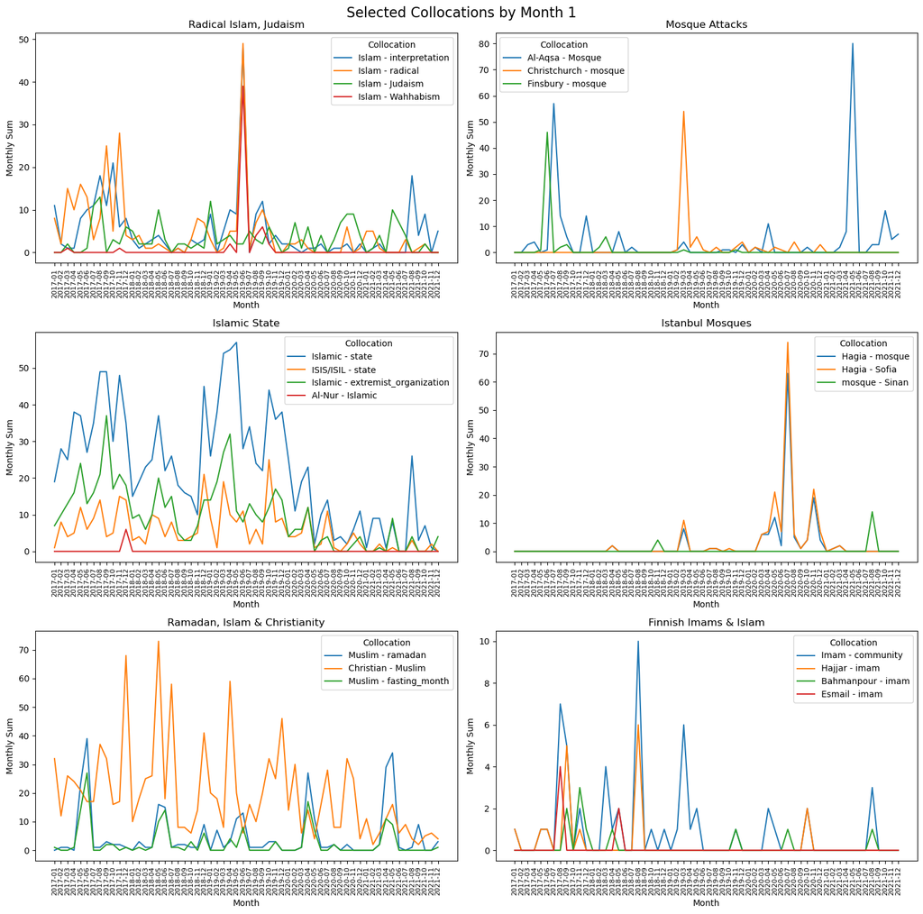

```python
makeplots(dfs=dfs,
              selected_sheets=group1,
              xcol='Month',
              y_var='Collocation',
              sum_specifier="Monthly",
              path="From collocation to timeline",
              title= "Selected Collocations by Month 1")
```

### Fig. 3. Selected collocations by month 2

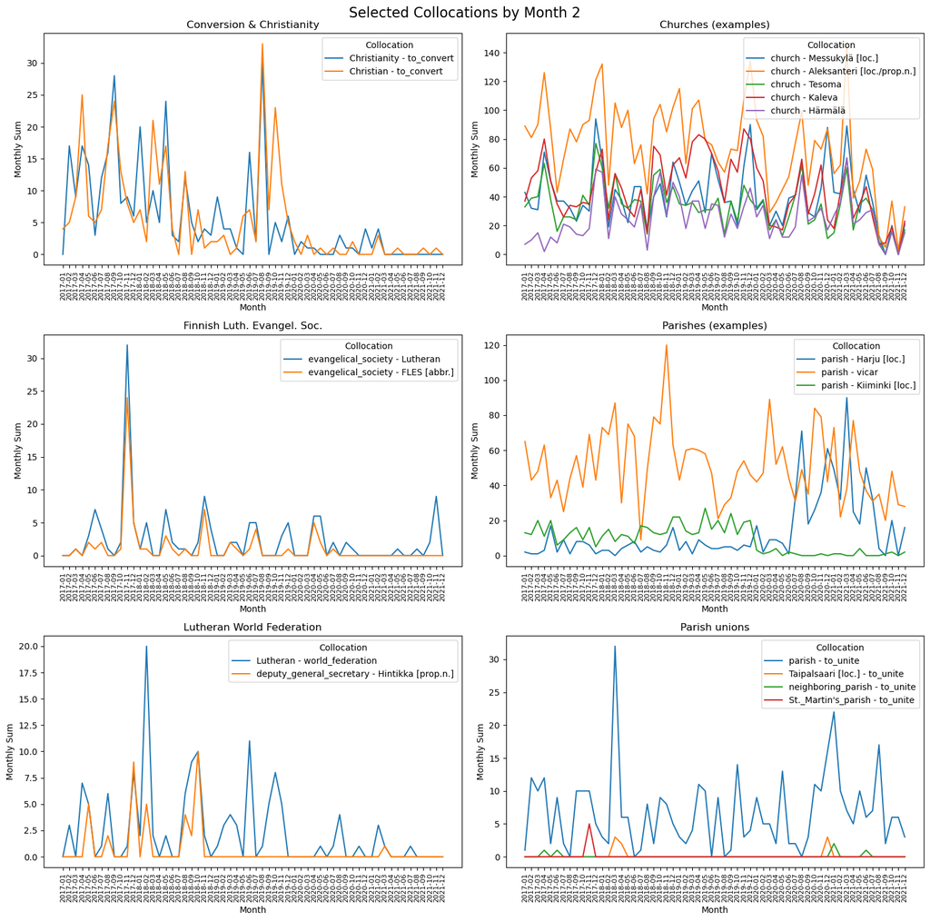

```python
makeplots(dfs=dfs,
              selected_sheets=group2,
              xcol='Month',
              y_var='Collocation',
              sum_specifier="Monthly",
              path="From collocation to timeline",
              title= "Selected Collocations by Month 2")
```

## Make diagrams from general data

```python
data['fixed_date'] = data['text_issue_date'].apply(fix_date_format)
```

```python
data.to_excel("./From collocation to timeline/3.1_fixed_dates.xlsx")
```

```python
# Load the Excel file
file_path = "./From collocation to timeline/titles&sterms_bd_copy.xlsx"  # Change this to your actual file path
sheets = pd.ExcelFile(file_path).sheet_names  # Get sheet names

# Read sheets into a list of DataFrames
dfs = [pd.read_excel(file_path, sheet_name=sheet) for sheet in sheets]

monthly_dfs = []
for df in dfs:
    df["Month"] = pd.to_datetime(df["Month"], format="%Y-%m-%d", errors="coerce")  # Convert to datetime
    df = df.resample("M", on="Month").sum().reset_index()  # Group by month & sum
    df["Month"] = df["Month"].dt.strftime("%Y-%m")  # Format as YYYY-MM (clean output)
    monthly_dfs.append(df)
```

### Fig. 4. Monthly concordances by media title and search term

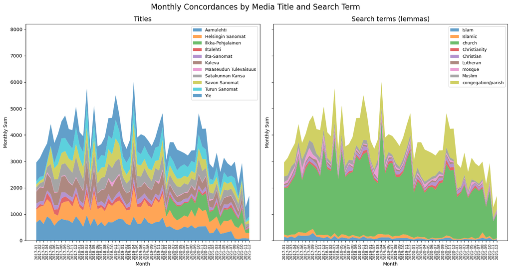

```python
fig, axes = plt.subplots(1, len(monthly_dfs), figsize=(15, 8), sharex=True, sharey=True)  # 1 row, N columns
colors = sns.color_palette("tab10")  # Get Seaborn color palette

for ax, df, sheet in zip(axes, monthly_dfs, sheets):  # Match DataFrames with sheet names and subplot axes
    months = df["Month"]  # X-axis
    data = df.drop(columns=["Month"]).T  # Drop 'Month' and 'Total' columns
    labels = data.index  # Collocate names

    ax.stackplot(months, data, labels=labels, colors=colors, alpha=0.7)  # Stacked area plot
    ax.set_title(sheet, fontsize=14)  # Set subplot title to sheet name
    ax.set_xlabel("Month")
    ax.set_ylabel("Monthly Sum")
    ax.tick_params(axis="x", rotation=90)  # Rotate x-axis labels
    ax.tick_params(axis='x', labelsize=8)

    ax.set_ylim(0, df.drop(columns=["Month"]).values.max() + 4000)

    ax.legend(title=None, fontsize=9, loc="upper right")  # Add legend

# Set overall title
plt.suptitle("Monthly Concordances by Media Title and Search Term", fontsize=16)
plt.tight_layout()
plt.savefig("./From collocation to timeline/mnlty_ccds_by_media_and_sterms.svg", format="svg", bbox_inches="tight")
plt.show()
```

## Listing of the nodes and edges in the collocation network

The following tables (1 & 2) are copied from Gephi and saved as xlsx.

### Table 1. Nodes in Finnish and English

```python
nodes_df = pd.read_excel("./From collocation to timeline/nodes.xlsx")

print(nodes_df.to_string())
```

```
                   Lemma (FI)                                    Lemma (EN)  Level       N  Mod. class  Dgr.
0                       islam                                     ST: Islam      0    6713           0    17
1                islamilainen                                   ST: Islamic      0    5436           1    21
2                    moskeija                                    ST: mosque      0    6061           6    19
3                     muslimi                                    ST: Muslim      0   10240           8    19
4                      kirkko                                    ST: Church      0  181777          10    18
5                  seurakunta                     ST: congregation / parish      0   64592          11    13
6                luterilainen                                  ST: Lutheran      0    4840          13    20
7                   kristitty                                 ST: Christian      0    8455          16    34
8                 kristinusko                              ST: Christianity      0    5276          18    18
9                   radikaali                                       radical      1     381           0    14
10               juutalaisuus                                       Judaism      1     216          19    25
11                   tulkinta                                interpretation      1     525           0    13
12                    uskonto                                      religion      1    1965          19    11
13                poliittinen                                     political      1     521           0    11
```

[output cut: 620 more lines]

Below in table 2, the edges, or connections between the node-lemmas are presented. Z-score has been used as the weight of the edges.

### Table 2. Edges in Finnish

```python
edges_df = pd.read_excel("./From collocation to timeline/edges.xlsx")
edges_df = edges_df.set_index("Edge Id").sort_index()
print(edges_df.to_string())
```

```
                      Source                    Target  Weight (z-score)
Edge Id
0                      islam                 radikaali         85.833564
1                      islam              juutalaisuus         77.236354
2                      islam                  tulkinta         74.365447
3                      islam                   uskonto         56.103243
4                      islam               poliittinen         55.193694
5                      islam              maahanmuutto         50.660083
6                      islam               wahhabismia         45.533133
7                      islam             buddhalaisuus         44.977903
8                      islam                    arabia         42.432320
9                      islam                terrorismi         40.954873
10                 radikaali               wahhabismia        179.279090
11                 radikaali                  levittää        103.331149
12                 radikaali                     islam         85.833564
```

[output cut: 954 more lines]